# STAT3926/STAT4026 Project

- Show All Code
- Hide All Code
- View Source

A Statistical Investigation into Sea Cucumber Species at One Tree Island

Authors

**SIDs**: 520468531, 510509099

**Client**: MARS 3: Qingyuan Xin

Published

May 23, 2024

**Code: Setup**

```r
library(tidyverse)
library(kableExtra)
library(rstatix)
library(ggpubr)
library(knitr)
library(broom)
library(DT)
library(janitor)
library(emmeans)
library(tippy)
library(ggfortify)
library(lmerTest)
library(pbkrtest)
library(stringr)
library(xfun)
library(MASS)
library(pubh)
library(pscl)
library(DHARMa)
library(performance)
library(equatiomatic) # remotes::install_github("datalorax/equatiomatic")
library(sjPlot)

orange = "#d85f33"
lightorange = "#fcbaa2"

tippy::tippy_this(elementId = "exact",
                  tooltip = "Calculated the p-value of the test based on all possible contingency tables with fixed row and column sums.")
```

[interactive chart not shown]

# 1 Executive Summary

The client conducted a study to observe the abundance of sea cucumbers in three sites at One Tree Island. These sites were chosen as they represent different levels of wave energy exposure, which may influence the characteristics of the habitat.

The client requested both proportion and count graphs visualising the distribution of species across the three sites. They also were interested in some statistical tests to determine whether site and/or habitat significantly impacts the abundance and/or proportion of sea cucumber species.

By utilising Fisher’s exact test for homogeneity it was found that the proportions of sea cucumber species are different in different sites ($p<0.00001$) and in different habitats ($p<0.00001$).

# 2 Goals of Analysis

After an initial consultation with the client and subsequent communication, two key goals for the project have been identified:

## 2.1 Key Goal 1

To determine if the proportions of sea cucumber species are significantly different in differing habitats and in differing sites.

## 2.2 Key Goal 2

To determine if the abundance of sea cucumber species is significantly different in differing sites and in differing habitats.

# 3 Datasets and Considerations

## 3.1 Datasets

The data was collected from One Tree Island, and collected in 2 Excel spreadsheets. The study was conducted in three sites, each with differing wave energy. Site 1 had the highest exposure of wave energy, whilst Site 3 had the least. Within the three sites, 8 transects were taken. For each of these transects, the Abundance of four sea cucumber species was recorded within an Excel spreadsheet.

Upon the client’s request, habitat categories were manually assigned based on the transects within each site. This assignment is below:

**Habitat 1**

- Site 1
  - Transect 1 to 7
- Site 2
  - Transect 1 to 7

**Habitat 2**

- Site 1
  - Transect 8
- Site 2
  - Transect 8

**Habitat 3**

- Site 3
  - Transect 1 to 8

## 3.2 Considerations

Due to the limited sample size, Fisher’s exact test for homogeneity was chosen over the more well-known Chi-squared test for homogeneity. Specifically, the assumption that the expected cell counts must be greater than or equal to $5$ that is used in the Chi-squared test for homogeneity was not met. This was likely due to the Actinopyga echinites (Red) species only being found in 1 transect.

Considering the specific characteristics of the provided data – including zero-inflation and over-dispersion – a negative binomial model was selected for implementation. This is a common model used to model count data which is both zero-inflated and over-dispersed.

# 4 Analysis

```r
data = read.csv("data/sea cucumber - Raw data.csv") |> clean_names()

# Read the data file into R and clean column names
data2 = read.csv("data/sea cucumber - Species distrubution and abundance.csv", na.strings = c("", "NA"), header = FALSE) |>
  clean_names()

# Identify empty rows (assuming empty rows are those with all NA values)
empty_rows = apply(data2, 1, function(row) all(is.na(row)))

# Remove empty rows
cleaned_data = data2[!empty_rows, ]

# Initializes long dataframe
sea_cucumber_data_long = data.frame(Site=c(), Transect=c(), Species=c(), Abundance=c())

current_species = NULL

# Generate long dataframe
for (index in 1:nrow(cleaned_data)) {
  if (cleaned_data[index, "v2"] == "Site 1") {
    current_species = cleaned_data[index, "v1"]
  }
  else {
    sea_cucumber_data_long = rbind(sea_cucumber_data_long,
                     data.frame(Site=c("Site 1"),
                                Transect=c(cleaned_data[index, "v1"]),
                                Species=c(current_species),
                                Abundance=c(cleaned_data[index, "v2"])))
   sea_cucumber_data_long = rbind(sea_cucumber_data_long,
                     data.frame(Site=c("Site 2"),
                                Transect=c(cleaned_data[index, "v1"]),
                                Species=c(current_species),
                                Abundance=c(cleaned_data[index, "v3"])))
    sea_cucumber_data_long = rbind(sea_cucumber_data_long,
                     data.frame(Site=c("Site 3"),
                                Transect=c(cleaned_data[index, "v1"]),
                                Species=c(current_species),
                                Abundance=c(cleaned_data[index, "v4"])))
  }
}

# d-type changes
sea_cucumber_data_long$Transect = as.numeric(grep_sub("Transect ", "", sea_cucumber_data_long$Transect))
sea_cucumber_data_long$Abundance = as.numeric(sea_cucumber_data_long$Abundance)
sea_cucumber_data_long$Species = factor(sea_cucumber_data_long$Species)
sea_cucumber_data_long$Site = factor(sea_cucumber_data_long$Site)

# Adding in Habitat
sea_cucumber_data_long = sea_cucumber_data_long |>
  mutate(Habitat = ifelse((Site %in% c("Site 1", "Site 2")) & (Transect %in% 1:7),
                                        "Habitat 1",
                                        ifelse(Site == "Site 3",
                                               "Habitat 3",
                                               "Habitat 2")))

# Adding proportion
totals_df = sea_cucumber_data_long |> group_by(Site, Transect) |> summarise(Transect_Total=sum(Abundance), .groups = "keep")
sea_cucumber_data_long = sea_cucumber_data_long |> left_join(totals_df)
sea_cucumber_data_long = sea_cucumber_data_long |> mutate(Proportion = Abundance/Transect_Total)
```

```r
# Generate extra long dataframe for Fisher test
sea_cucumber_data_extra_long = data.frame(Site=c(), Species=c(), Transect=c())

for (index in 1:nrow(sea_cucumber_data_long)) {
  sea_cucumber_data_extra_long = rbind(sea_cucumber_data_extra_long,
                                       data.frame(Site=rep(sea_cucumber_data_long[index, "Site"],
                                                           sea_cucumber_data_long[index, "Abundance"]),
                                                  Species=rep(sea_cucumber_data_long[index, "Species"],
                                                           sea_cucumber_data_long[index, "Abundance"]),
                                                  Transect=rep(sea_cucumber_data_long[index, "Transect"],
                                                           sea_cucumber_data_long[index, "Abundance"]),
                                                  Habitat=rep(sea_cucumber_data_long[index, "Habitat"],
                                                           sea_cucumber_data_long[index, "Abundance"])))
}
```

## 4.1 Key Goal 1

**Key Goal 1**: To determine if the proportions of sea cucumber species are significantly different in differing habitats and in differing sites.

**Statistical Approach**: In order to answer this goal, Fisher’s exact test for homogeneity was performed. This exact statistical test determines if the proportions for the outcome variable (Species) are the same across the populations (Site/Habitat). A Fisher’s exact test was used as the assumptions of a Chi-squared test for homogeneity were not met (the expected cell count was not all $\geq 5$). These two tests have the same null and alternative hypothesis, and only differ by how they calculate the $p$-value of the test.

Visualisations of the data and the results of the tests are given below:

**Site**

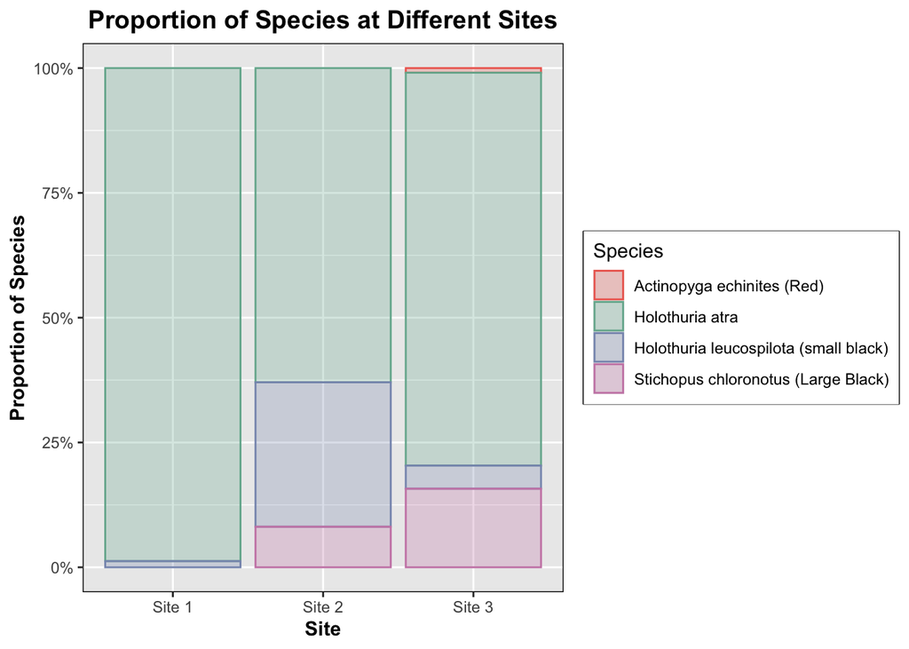

Figure 1: Proportion of differing sea cucumber species in the three sites sampled.

```r
sea_cucumber_data_extra_long |> ggplot() +
  aes(x=Site, fill=Species, color=Species) +
  geom_bar(position="fill") +
  scale_fill_manual(values=c('Holothuria atra' = "#75b29c46", "Stichopus chloronotus (Large Black)" = "#ca86b346", "Holothuria leucospilota (small black)" = "#8796ba46", "Actinopyga echinites (Red)" = "#ed6a5e46")) +
  scale_color_manual(values=c('Holothuria atra' = "#75b29c", "Stichopus chloronotus (Large Black)" = "#ca86b3", "Holothuria leucospilota (small black)" = "#8796ba", "Actinopyga echinites (Red)" = "#ed6a5e")) +
    labs(title="Proportion of Species at Different Sites") +
    labs(x="Site",
         y="Proportion of Species") +
    scale_y_continuous(labels = scales::percent) +
    theme(plot.background = element_rect(fill = "#ffffff",
                                         linewidth = 0),
          panel.border = element_rect(colour = "black",
                                      fill=NA),
          legend.box.background = element_rect(colour = "black"),
          axis.title = element_text(face="bold"),
          plot.title = element_text(face="bold",
                                    size = 14,
                                    hjust = 0.5))
```

The above figure (Figure 1) shows the relative proportions of different species found within the three sites surveyed. We can see that Holothuria atra dominates the proportions, with it comprising the majority of sea cucumbers observed in each site. It is interesting to note that the proportion of Stichopus chloronotus (Large Black) cucumbers increased from Site 1 to Site 3, which may indicate that Stichopus chloronotus (Large Black) cucumbers do not tolerate high wave energy exposure well.

```r
# Make contingency table
tab <- xtabs(~ Site + Species, data = sea_cucumber_data_extra_long)

kable(tab)
```

Table 1: Contingency Table of the Abundance of Seas Cucumbers Species in the Three Sites

|  | Actinopyga echinites (Red) | Holothuria atra | Holothuria leucospilota (small black) | Stichopus chloronotus (Large Black) |
| --- | --- | --- | --- | --- |
| Site 1 | 0 | 80 | 1 | 0 |
| Site 2 | 0 | 124 | 57 | 16 |
| Site 3 | 1 | 85 | 5 | 17 |

```r
# Run test
test = fisher.test(tab)
```

**Fisher’s Exact Test for Homogeneity ($\alpha=0.05$)**

1. **Hypothesis** – $H_0$: The proportions for the sea cucumber species are the same across the three sites. $H_1$: The proportions for the sea cucumber species are different for at least two of the three sites.
2. **Assumptions** - All observations were randomly sampled from the three sites. This is likely to be true as the transects occurred across the whole site.
3. **p-value** – $p=$ <0.00001.
4. **Decision** – As the $p$ -value was $<\alpha$, we can reject $H_0$. This implies that the proportions for the sea cucumber species are different for at least two of the three sites.

**Habitat**

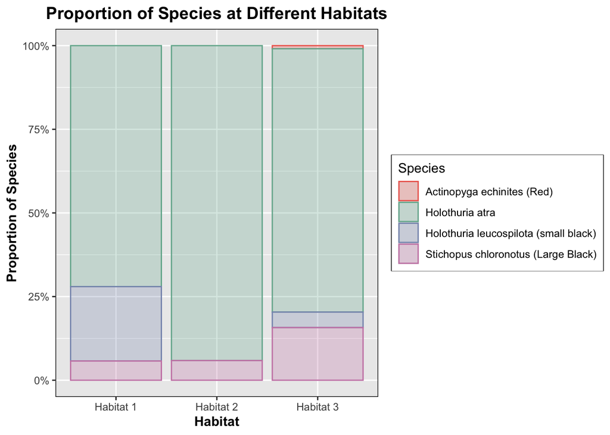

Figure 2: Proportion of differing sea cucumber species in the three habitats sampled.

```r
sea_cucumber_data_extra_long |> ggplot() +
  aes(x=Habitat, fill=Species, color=Species) +
  geom_bar(position="fill") +
  scale_fill_manual(values=c('Holothuria atra' = "#75b29c46", "Stichopus chloronotus (Large Black)" = "#ca86b346", "Holothuria leucospilota (small black)" = "#8796ba46", "Actinopyga echinites (Red)" = "#ed6a5e46")) +
  scale_color_manual(values=c('Holothuria atra' = "#75b29c", "Stichopus chloronotus (Large Black)" = "#ca86b3", "Holothuria leucospilota (small black)" = "#8796ba", "Actinopyga echinites (Red)" = "#ed6a5e")) +
    labs(title="Proportion of Species at Different Habitats") +
    labs(x="Habitat",
         y="Proportion of Species") +
    scale_y_continuous(labels = scales::percent) +
    theme(plot.background = element_rect(fill = "#ffffff",
                                         linewidth = 0),
          panel.border = element_rect(colour = "black",
                                      fill=NA),
          legend.box.background = element_rect(colour = "black"),
          axis.title = element_text(face="bold"),
          plot.title = element_text(face="bold",
                                    size = 14,
                                    hjust = 0.5))
```

The above figure (Figure 2) shows the relative proportions of different species found within the three habitats surveyed. We can see that Holothuria atra dominates the proportions, with it comprising the majority of sea cucumbers observed in each habitat.

```r
# Make contingency table
tab <- xtabs(~Habitat + Species, data = sea_cucumber_data_extra_long)

kable(tab)
```

Table 2: Contingency Table of the Abundance of Seas Cucumbers Species in the Three Habitats

|  | Actinopyga echinites (Red) | Holothuria atra | Holothuria leucospilota (small black) | Stichopus chloronotus (Large Black) |
| --- | --- | --- | --- | --- |
| Habitat 1 | 0 | 188 | 58 | 15 |
| Habitat 2 | 0 | 16 | 0 | 1 |
| Habitat 3 | 1 | 85 | 5 | 17 |

```r
# Run test
test = fisher.test(tab)
```

**Fisher’s Exact Test for Homogeneity ($\alpha=0.05$)**

1. **Hypothesis** – $H_0$: The proportions for the sea cucumber species are the same across the three habitats. $H_1$: The proportions for the sea cucumber species are different for at least two of the three habitats.
2. **Assumptions** - All observations were randomly sampled from the three habitats. This is likely to be true as the transects occurred across the whole habitats.
3. **p-value** – $p=$ <0.00001.
4. **Decision** – As the $p$ -value was $<\alpha$, we can reject $H_0$. This implies that the proportions for the sea cumber species are different for at least two of the three habitats.

Both tests gave statistically significant results, and as such it can be concluded that the proportion of sea cucumbers differs between sites and between habitats.

## 4.2 Key Goal 2

**Key Goal 2**: To determine if the abundance of sea cucumber species is significantly different in differing sites and in differing habitats.

**Statistical Approach**: For a given impact factor (Site and Habitat) create two Negative Binomial Models (NBM) to model Abundance of different sea cucumbers in a transect. Each model includes the impact of species. This is done as some species may be rarer than others irrespective of the site and/or habitat they come from. The ‘full model’ includes the effect of Site/Habitat. For example:

$$\text{Abundance} \sim \text{Species} + \text{Site}$$

The ‘null model’ does not include the effect of Site/Habitat:
$$\text{Abundance} \sim \text{Species}$$

These two NBMs were compared using an ANOVA to determine whether the effect of Site/Habitat is significant on Abundance when also considering the Species of the sea cucumber. This is done by comparing the full and null models. If this test has a significant result, it implies that Abundance differs significantly across different Sites/Habitat when compared to the overall expected Count of the Species.

Visualisations of the data and the results of the tests are given below:

**Site**

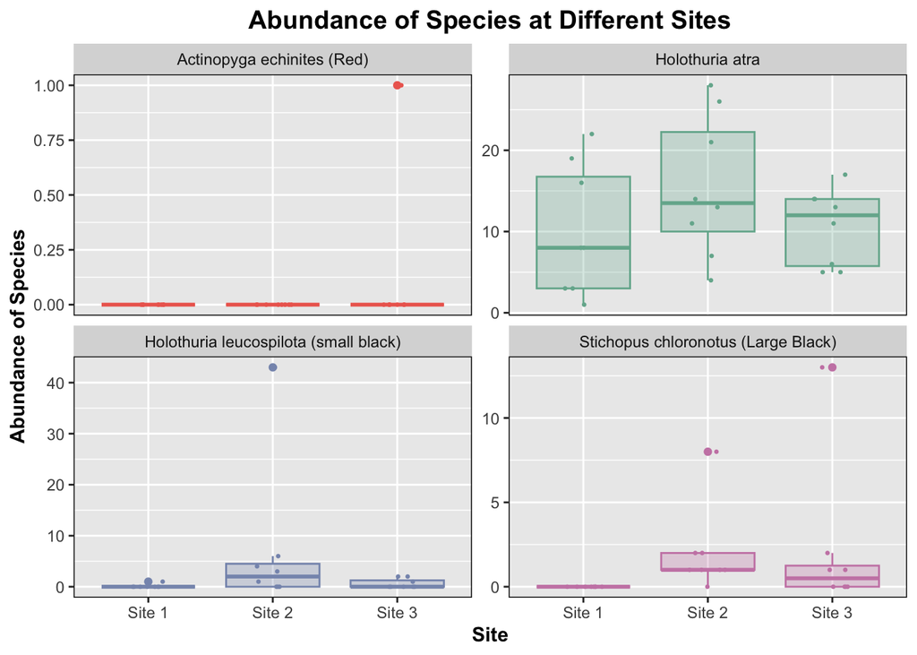

(a) Free y-axis

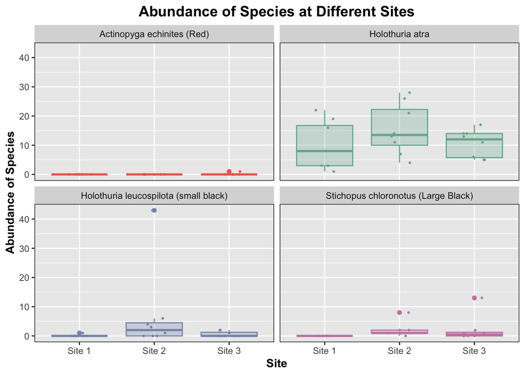

(b) Fixed y-axis

Figure 3: Abundance of differing sea cucumber species in the three sites sampled.

```r
sea_cucumber_data_long |> ggplot() +
  aes(x=Site, fill=Species, color=Species, y=Abundance) +
  facet_wrap(~Species, scales="free_y") +
  geom_boxplot() +
  geom_jitter(height=0, width=0.15, size=0.5) +
  scale_fill_manual(values=c('Holothuria atra' = "#75b29c46", "Stichopus chloronotus (Large Black)" = "#ca86b346", "Holothuria leucospilota (small black)" = "#8796ba46", "Actinopyga echinites (Red)" = "#ed6a5e46")) +
  scale_color_manual(values=c('Holothuria atra' = "#75b29c", "Stichopus chloronotus (Large Black)" = "#ca86b3", "Holothuria leucospilota (small black)" = "#8796ba", "Actinopyga echinites (Red)" = "#ed6a5e")) +
    labs(title="Abundance of Species at Different Sites") +
    labs(x="Site",
         y="Abundance of Species") +
    theme(plot.background = element_rect(fill = "#ffffff",
                                         linewidth = 0),
          panel.border = element_rect(colour = "black",
                                      fill=NA),
          legend.position = "hide",
          axis.title = element_text(face="bold"),
          plot.title = element_text(face="bold",
                                    size = 14,
                                    hjust = 0.5))

sea_cucumber_data_long |> ggplot() +
  aes(x=Site, fill=Species, color=Species, y=Abundance) +
  facet_wrap(~Species) +
  geom_boxplot() +
  geom_jitter(height=0, width=0.15, size=0.5) +
  scale_fill_manual(values=c('Holothuria atra' = "#75b29c46", "Stichopus chloronotus (Large Black)" = "#ca86b346", "Holothuria leucospilota (small black)" = "#8796ba46", "Actinopyga echinites (Red)" = "#ed6a5e46")) +
  scale_color_manual(values=c('Holothuria atra' = "#75b29c", "Stichopus chloronotus (Large Black)" = "#ca86b3", "Holothuria leucospilota (small black)" = "#8796ba", "Actinopyga echinites (Red)" = "#ed6a5e")) +
    labs(title="Abundance of Species at Different Sites") +
    labs(x="Site",
         y="Abundance of Species") +
    theme(plot.background = element_rect(fill = "#ffffff",
                                         linewidth = 0),
          panel.border = element_rect(colour = "black",
                                      fill=NA),
          legend.position = "hide",
          axis.title = element_text(face="bold"),
          plot.title = element_text(face="bold",
                                    size = 14,
                                    hjust = 0.5))
```

The above plot (Figure 3) shows the distribution (as visualised with a boxplot) of species abundance at the three different sites (noting the different scales in the two graphs). Each data point corresponds to one transect within the given site.

It is observed that many transects did not find any of some species For example, only one sample observed an Actinopyga echinites (Red) cucumber. There are also outliers seen within all species apart from Holothuria atra. One such example is the count of $43$ Holothuria leucospilota (small black) cucumbers in one transect of Site 2. This may have been a mistake in data entry.

```r
# Generate models
null_model = glm.nb(Abundance~ Species, data=sea_cucumber_data_long)
full_model = glm.nb(Abundance~ Species+Site, data=sea_cucumber_data_long)

# Run test
a = anova(full_model, null_model)
colnames(a) = c("Model", "Theta", "Resid. Df", "2 x log-lik.", "Test", "Df", "LR Stat.", "p-value")

kable(a, digits=c(0,3,9,1,0,0,3,4))
```

Summary Table of Likelihood Ratio Test of Negative Binomial Models - Site Significance

| Model | Theta | Resid. Df | 2 x log-lik. | Test | Df | LR Stat. | p-value |
| --- | --- | --- | --- | --- | --- | --- | --- |
| Species | 0.556 | 92 | -351.5 |  | NA | NA | NA |
| Species + Site | 0.741 | 90 | -335.0 | 1 vs 2 | 2 | 16.57 | 3e-04 |

The likelihood ratio test yielded a significant result ($p < 0.05$), indicating that the Species + Site model provides a significantly better fit to the data compared to the Species-only model. The significant improvement in model fit with the inclusion of Site as a predictor suggests that site-specific factors play a crucial role in determining sea cucumber counts.

### Full Model

```r
sjPlot::tab_model(full_model, show.intercept = TRUE,
                  show.se = FALSE, dv.labels = "Predictors of the Abundance of Sea Cucumbers",
                  auto.label = TRUE, show.re.var = FALSE, show.icc = FALSE,
                  show.ngroups = FALSE, show.obs = FALSE, show.r2 = FALSE)
```

|  | Predictors of the Abundance of Sea Cucumbers |  |  |
| --- | --- | --- | --- |
| Predictors | Incidence Rate Ratios | CI | p |
| (Intercept) | 0.01 | 0.00 – 0.08 | **<0.001** |
| Species [Holothuria atra] | 402.39 | 71.36 – 7669.01 | **<0.001** |
| Species [Holothuria leucospilota (small black)] | 45.73 | 8.17 – 863.86 | **<0.001** |
| Species [Stichopus chloronotus (Large Black)] | 31.92 | 5.59 – 609.11 | **0.001** |
| Site [Site 2] | 5.98 | 2.59 – 14.46 | **<0.001** |
| Site [Site 3] | 2.61 | 1.14 – 6.25 | **0.021** |

**Species Variation**: Different species of sea cucumbers exhibit varied associations with the abundance of sea cucumbers in different sites. Holothuria atra demonstrates a substantially higher incidence rate compared to other species, with an IRR of 402.39 (95% CI: 71.36 – 7669.01, p < 0.001). Similarly, Holothuria leucospilota (Small black) and Stichopus chloronotus (Large Black) exhibit elevated incidence rates compared to the reference category(Actinopyga echinites (Red)), (IRR = 45.73 and 31.92, respectively).

**Site Influence**: The site of observation plays a significant role in the abundance of different types of sea cucumbers. Site 2 shows a nearly sixfold increase in incidence rates compared to the reference site(Site 1) (IRR = 5.98, 95% CI: 2.59 – 14.46, p < 0.001), while Site 3 demonstrates a more moderate association (IRR = 2.61, 95% CI: 1.14 – 6.25, p = 0.021).

These findings suggest that both species variation and site characteristics are important determinants of the abundance of sea cucumbers.

#### Full Model Equation

```r
extract_eq(full_model, wrap=TRUE, terms_per_line = 1, use_coefs = TRUE)
```

$$\begin{aligned}
\log ({ \widehat{E( \operatorname{Abundance} )} }) &= -4.31\ + \\
&\quad 6(\operatorname{Species}_{\operatorname{Holothuria\ atra}})\ + \\
&\quad 3.82(\operatorname{Species}_{\operatorname{Holothuria\ leucospilota\ (small\ black)}})\ + \\
&\quad 3.46(\operatorname{Species}_{\operatorname{Stichopus\ chloronotus\ (Large\ Black)}})\ + \\
&\quad 1.79(\operatorname{Site}_{\operatorname{\ 2}})\ + \\
&\quad 0.96(\operatorname{Site}_{\operatorname{\ 3}})
\end{aligned}$$

This equation expresses the relationship between the log of the expected abundance of sea cucumbers and the predictor variables (Species and Site) in the model. The intercept (-4.3089) represents “Site 1” and “Actinopyga echinites (Red)” that were set as reference levels for the categorical variables “Site” and “Species”

The coefficients for the other levels of the variables represent the differences in the expected log abundance compared to the reference levels. The coefficients for the other levels of the variables represent the differences in the expected log abundance compared to the reference levels. For example, the coefficients for “Site 2 (1.79)” and “Site 3 (0.96)” indicate the differences in expected log abundance between these sites and “Site 1”, and the coefficient for “SpeciesHolothuria atra” (5.9974) indicates that the expected log abundance for “Holothuria atra” is 5.9974 units higher than the expected log abundance for “Actinopyga echinites (Red)”.

**Habitat**

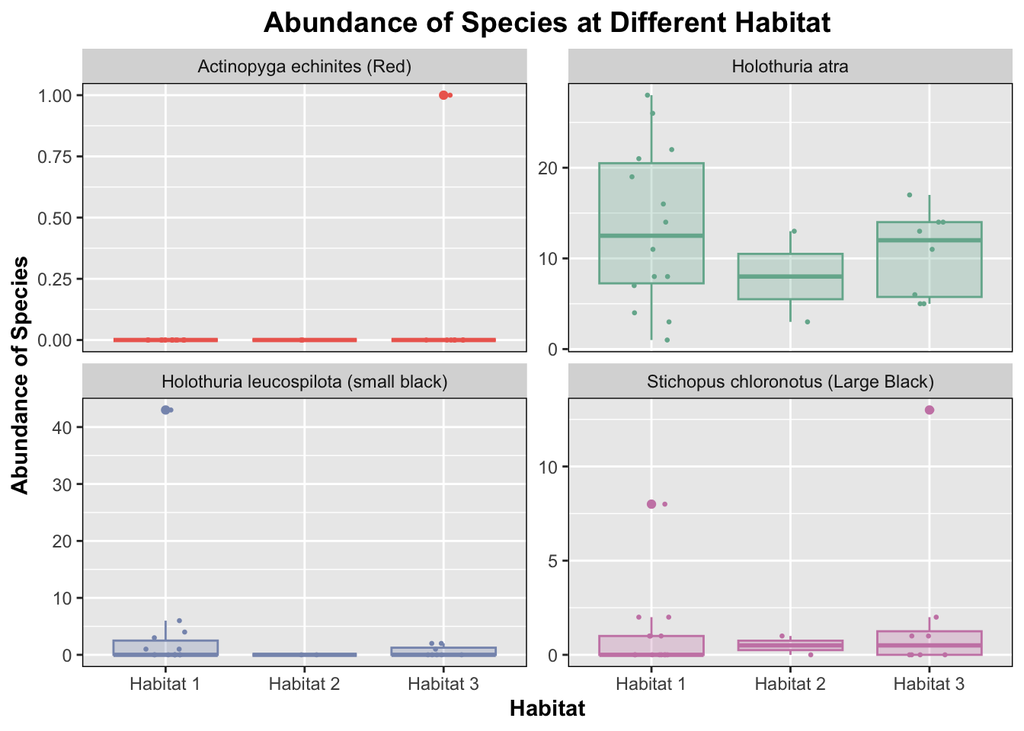

(a) Free y-axis

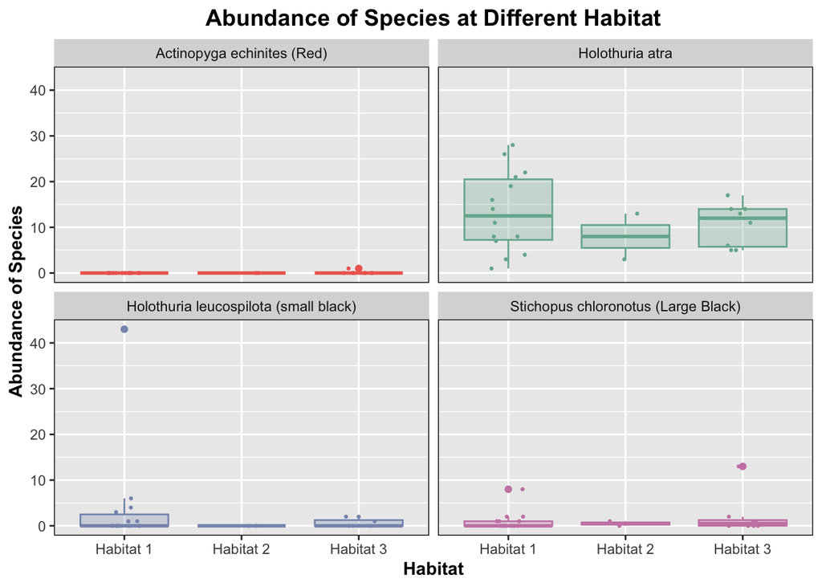

(b) Fixed y-axis

Figure 4: Abundance of differing sea cucumber species in the three habitats sampled.

```r
sea_cucumber_data_long |> ggplot() +
  aes(x=Habitat, fill=Species, color=Species, y=Abundance) +
  facet_wrap(~Species, scales="free_y") +
  geom_boxplot() +
  geom_jitter(height=0, width=0.15, size=0.5) +
  scale_fill_manual(values=c('Holothuria atra' = "#75b29c46", "Stichopus chloronotus (Large Black)" = "#ca86b346", "Holothuria leucospilota (small black)" = "#8796ba46", "Actinopyga echinites (Red)" = "#ed6a5e46")) +
  scale_color_manual(values=c('Holothuria atra' = "#75b29c", "Stichopus chloronotus (Large Black)" = "#ca86b3", "Holothuria leucospilota (small black)" = "#8796ba", "Actinopyga echinites (Red)" = "#ed6a5e")) +
    labs(title="Abundance of Species at Different Habitat") +
    labs(x="Habitat",
         y="Abundance of Species") +
    theme(plot.background = element_rect(fill = "#ffffff",
                                         linewidth = 0),
          panel.border = element_rect(colour = "black",
                                      fill=NA),
          legend.position = "hide",
          axis.title = element_text(face="bold"),
          plot.title = element_text(face="bold",
                                    size = 14,
                                    hjust = 0.5))

sea_cucumber_data_long |> ggplot() +
  aes(x=Habitat, fill=Species, color=Species, y=Abundance) +
  facet_wrap(~Species) +
  geom_boxplot() +
  geom_jitter(height=0, width=0.15, size=0.5) +
  scale_fill_manual(values=c('Holothuria atra' = "#75b29c46", "Stichopus chloronotus (Large Black)" = "#ca86b346", "Holothuria leucospilota (small black)" = "#8796ba46", "Actinopyga echinites (Red)" = "#ed6a5e46")) +
  scale_color_manual(values=c('Holothuria atra' = "#75b29c", "Stichopus chloronotus (Large Black)" = "#ca86b3", "Holothuria leucospilota (small black)" = "#8796ba", "Actinopyga echinites (Red)" = "#ed6a5e")) +
    labs(title="Abundance of Species at Different Habitat") +
    labs(x="Habitat",
         y="Abundance of Species") +
    theme(plot.background = element_rect(fill = "#ffffff",
                                         linewidth = 0),
          panel.border = element_rect(colour = "black",
                                      fill=NA),
          legend.position = "hide",
          axis.title = element_text(face="bold"),
          plot.title = element_text(face="bold",
                                    size = 14,
                                    hjust = 0.5))
```

The above plot (Figure 4) shows the distribution (as visualised with a boxplot) of species abundance at the three different habitats (noting the different scales for the four panels). Each data point corresponds to one transect within the given habitat.

```r
# Generate models
null_model = glm.nb(Abundance~ Species, data=sea_cucumber_data_long)
full_model = glm.nb(Abundance~ Species+Habitat, data=sea_cucumber_data_long)

# Run test
a = anova(full_model, null_model)
colnames(a) = c("Model", "Theta", "Resid. Df", "2 x log-lik.", "Test", "Df", "LR Stat.", "p-value")

kable(a, digits=c(0,3,9,1,0,0,3,4))
```

Summary Table of Likelihood Ratio Tests of Negative Binomial Models - Habitat Significance

| Model | Theta | Resid. Df | 2 x log-lik. | Test | Df | LR Stat. | p-value |
| --- | --- | --- | --- | --- | --- | --- | --- |
| Species | 0.556 | 92 | -351.5 |  | NA | NA | NA |
| Species + Habitat | 0.589 | 90 | -348.9 | 1 vs 2 | 2 | 2.594 | 0.2733 |

The likelihood ratio test did not yield a significant result ($p > 0.05$), indicating that the Species + Habitat model does not provide a significantly better fit to the data compared to the Species-only model. This suggests that incorporating information about habitat type did not substantially improve our ability to predict sea cucumber counts beyond what is explained by species alone. The lack of significance suggests that Habitat type may not be a strong predictor of sea cucumber counts in this analysis.

### Full Model

```r
sjPlot::tab_model(full_model, show.intercept = TRUE,
                  show.se = FALSE, dv.labels = "Predictors of the Abundance of Sea Cucumbers",
                  auto.label = TRUE, show.re.var = FALSE, show.icc = FALSE,
                  show.ngroups = FALSE, show.obs = FALSE, show.r2 = FALSE)
```

|  | Predictors of the Abundance of Sea Cucumbers |  |  |
| --- | --- | --- | --- |
| Predictors | Incidence Rate Ratios | CI | p |
| (Intercept) | 0.05 | 0.00 – 0.25 | **0.004** |
| Species [Holothuria atra] | 297.45 | 53.77 – 5605.85 | **<0.001** |
| Species [Holothuria leucospilota (small black)] | 57.26 | 10.14 – 1086.39 | **<0.001** |
| Species [Stichopus chloronotus (Large Black)] | 33.97 | 5.92 – 648.55 | **0.001** |
| Habitat [Habitat 2] | 0.32 | 0.09 – 1.36 | 0.097 |
| Habitat [Habitat 3] | 0.77 | 0.36 – 1.68 | 0.472 |

Similarly, different species of sea cucumbers exhibit varied associations with the abundance of sea cucumbers in different habitats. Holothuria atra demonstrates a substantially higher incidence rate compared to other species, with an IRR of 297.45 (95% CI: 53.77 – 5605.85, p < 0.001). Holothuria leucospilota (Small black) and Stichopus chloronotus (Large Black) exhibit elevated incidence rates compared to the reference category(Actinopyga echinites (Red)), (IRR = 57.26 and 33.97, respectively).

Different types of habitats do not impose significant roles in the abundance of sea cucumbers (p >0.05).

These findings suggest that although species variation was an important determinant of the abundance of sea cucumbers, habitats were not a significant determinant of the abundance of sea cucumbers.

#### Full Model Equation

```r
extract_eq(full_model, wrap=TRUE, terms_per_line = 1, use_coefs = TRUE)
```

$$\begin{aligned}
\log ({ \widehat{E( \operatorname{Abundance} )} }) &= -3.02\ + \\
&\quad 5.7(\operatorname{Species}_{\operatorname{Holothuria\ atra}})\ + \\
&\quad 4.05(\operatorname{Species}_{\operatorname{Holothuria\ leucospilota\ (small\ black)}})\ + \\
&\quad 3.53(\operatorname{Species}_{\operatorname{Stichopus\ chloronotus\ (Large\ Black)}})\ - \\
&\quad 1.14(\operatorname{Habitat}_{\operatorname{\ 2}})\ - \\
&\quad 0.26(\operatorname{Habitat}_{\operatorname{\ 3}})
\end{aligned}$$

Similarly, this equation expresses the relationship between the log of the expected abundance of sea cucumbers and the predictor variables (Species and Habitat) in the model. The intercept (-3.02) represents “Habitat 1” and “Actinopyga echinites (Red)” that were set as reference levels for the categorical variables “Habitat” and “Species”

The coefficients for the other levels of the variables represent the differences in the expected log abundance compared to the reference levels. For example, the coefficients for “Habitat 2 (-1.14)” and “Habitat 3 (-0.26)” indicate the differences in expected log abundance between these sites and “Habitat 1”, but their associated p-values were greater than 0.05, indicating that these variables did not significantly contribute to the model.

# 5 Conclusion

By generating proportion and abundance graphs, the distribution of sea cucumber species becomes more apparent. A variety of statistical methods were then used to answer the key goals of the client.

By using Fisher’s exact test for homogeneity, the statistical significance in the proportions for species differing across sites and habitats. Through the use of a Likelihood Ratio Test, it was found that the site significantly influences the abundance of sea cucumber species. There was no significant difference found when investigating the impact of habitat on abundance.

# 6 Appendix

## Model Selection Results

The model selection process involved assessing different models to determine the most appropriate approach for analyzing the data. The following tables summarize the results of the model selection based on various criteria such as AIC (Akaike Information Criterion) and BIC (Bayesian Information Criterion) values.

```r
# Fit Poisson regression model
poisson_model <- glm(Abundance ~ Species + Site, data = sea_cucumber_data_long, family = poisson)

poisson_model2 <- glm(Abundance ~ Species + Habitat, data = sea_cucumber_data_long, family = poisson)

# Fit negative regression model
nbModel <- glm.nb(Abundance ~Species+ Site, data = sea_cucumber_data_long)
nbModel2<- glm.nb(Abundance ~ Species+ Habitat, data = sea_cucumber_data_long)

#Fit hurdle model
model.hp <- hurdle(Abundance ~ Species+ Site | Site, data = sea_cucumber_data_long)
model.hp2 <- hurdle(Abundance ~ Species+ Habitat | Habitat, data = sea_cucumber_data_long)


#Fit zero-inflation model
model.zi <- zeroinfl(Abundance ~ Species+ Site | Site, data = sea_cucumber_data_long)
model.zi2 <- zeroinfl(Abundance ~ Species+ Habitat | Habitat, data = sea_cucumber_data_long)

#checking zero-inflation assumptions under negative binomail regression models and poisson regression models
```

## 6.1 Zero Inflation

During EDA, checks for zero-inflation conducted during the model selection process were done. The ratios of observed to predicted zeros are provided along with interpretations for each model. The Negative Binomial Models show the ratio of observed and predicted zeros is within the tolerance range, whereas the Poisson Model is underfitting zeros, meaning zero-inflation.

### 6.1.1 Negative Binomial

**Site**

```r
x1 = capture.output(check_zeroinflation(nbModel))
```

```
Model seems ok, ratio of observed and predicted zeros is within the
  tolerance range (p = 0.576).
```

```r
for (x in x1[3:length(x1)]) {
  cat(x)
  cat("\n\n")
}
```

Observed zeros: 51

Predicted zeros: 49

```
        Ratio: 0.95
```

**Habitat**

```r
x1 = capture.output(check_zeroinflation(nbModel2))
```

```
Model seems ok, ratio of observed and predicted zeros is within the
  tolerance range (p = 0.608).
```

```r
for (x in x1[3:length(x1)]) {
  cat(x)
  cat("\n\n")
}
```

Observed zeros: 51

Predicted zeros: 48

```
        Ratio: 0.95
```

### 6.1.2 Poisson

**Site**

```r
x1 = capture.output(check_zeroinflation(poisson_model))
```

```
Model is underfitting zeros (probable zero-inflation).
```

```r
for (x in x1[3:length(x1)]) {
  cat(x)
  cat("\n\n")
}
```

Observed zeros: 51

Predicted zeros: 32

```
        Ratio: 0.63
```

**Habitat**

```r
x1 = capture.output(check_zeroinflation(poisson_model2))
```

```
Model is underfitting zeros (probable zero-inflation).
```

```r
for (x in x1[3:length(x1)]) {
  cat(x)
  cat("\n\n")
}
```

Observed zeros: 51

Predicted zeros: 31

```
        Ratio: 0.61
```

## 6.2 AIC

```r
# AIC & BIC test tell us NB model is the best model to fit the data

aic_values1 <- data.frame(
  Model = c("Hurdle", "Poisson", "Zero-inflation", "Negative Binomial"),
  AIC_Value = c(AIC(model.hp), AIC(poisson_model), AIC(model.zi), AIC(nbModel))
)

# Create data frames for the second set of models
aic_values2 <- data.frame(
  Model = c("Hurdle", "Poisson", "Zero-inflation", "Negative Binomial"),
  AIC_Value = c(AIC(model.hp2), AIC(poisson_model2), AIC(model.zi2), AIC(nbModel2))
)
```

**Site**

```r
kable(aic_values1)
```

AIC Values for Site Models

| Model | AIC_Value |
| --- | --- |
| Hurdle | 541.7446 |
| Poisson | 563.5269 |
| Zero-inflation | 508.7575 |
| Negative Binomial | 348.9575 |

**Habitat**

```r
kable(aic_values2)
```

AIC Values for Habitat Models

| Model | AIC_Value |
| --- | --- |
| Hurdle | 558.9859 |
| Poisson | 600.9864 |
| Zero-inflation | 530.1601 |
| Negative Binomial | 362.9328 |

## 6.3 BIC

```r
# Create data frames for the first set of models
bic_values1 <- data.frame(
  Model = c("Hurdle", "Poisson", "Zero-inflation", "Negative Binomial"),
  BIC_Value = c(BIC(model.hp), BIC(poisson_model), BIC(model.zi), BIC(nbModel))
)

# Create data frames for the second set of models
bic_values2 <- data.frame(
  Model = c("Hurdle", "Poisson", "Zero-inflation", "Negative Binomial"),
  BIC_Value = c(BIC(model.hp2), BIC(poisson_model2), BIC(model.zi2), BIC(nbModel2))
)
```

**Site**

```r
kable(bic_values1)
```

BIC Values for Site Models

| Model | BIC_Value |
| --- | --- |
| Hurdle | 564.8237 |
| Poisson | 578.9130 |
| Zero-inflation | 531.8367 |
| Negative Binomial | 366.9079 |

**Habitat**

```r
kable(bic_values2)
```

BIC Values for Habitat Models

| Model | BIC_Value |
| --- | --- |
| Hurdle | 582.0650 |
| Poisson | 616.3725 |
| Zero-inflation | 553.2392 |
| Negative Binomial | 380.8833 |

## 6.4 AIC & BIC Interpretation:

AIC and BIC are information criteria used for model selection. Lower values indicate better model fit. In both Model Set 1 and Model Set 2, the Negative Binomial model consistently has the lowest AIC and BIC values compared to other models.

The Negative Binomial model is chosen as the most appropriate model for analyzing the data due to its superior fit based on AIC and BIC values.